# Function of the Week:

Ashley Blair

02/03/2022

# Submission Instructions

Please sign up for a function here: https://docs.google.com/spreadsheets/d/1-RWAQTlLwttjFuZVAtSs8OiHIwu6AZLUdWugIHHTWVo/edit?usp=sharing

For this assignment, please submit both the `.Rmd` and the `.html` files. I will add it to the website. Remove your name from the Rmd if you do not wish it shared. If you select a function which was [presented last year](https://sph-r-programming.netlify.app/functions/), please develop your own examples and content.

# `Breaks_Pretty`

In this document, I will introduce the Breaks_Pretty function and show what it’s for.

```r
#load tidyverse up
library(tidyverse)
#example dataset
library(palmerpenguins)

#breaks pretty is in "scales" package
library(scales)
```

## What is it for?

The breaks_pretty function is used to create easy, incremental break formatting - n= will specify the amount of breaks. This function is used more commonly for dates/times. Extended_breaks() is more commonly used for numeric scales. In the example below, I used numeric variables anyway.

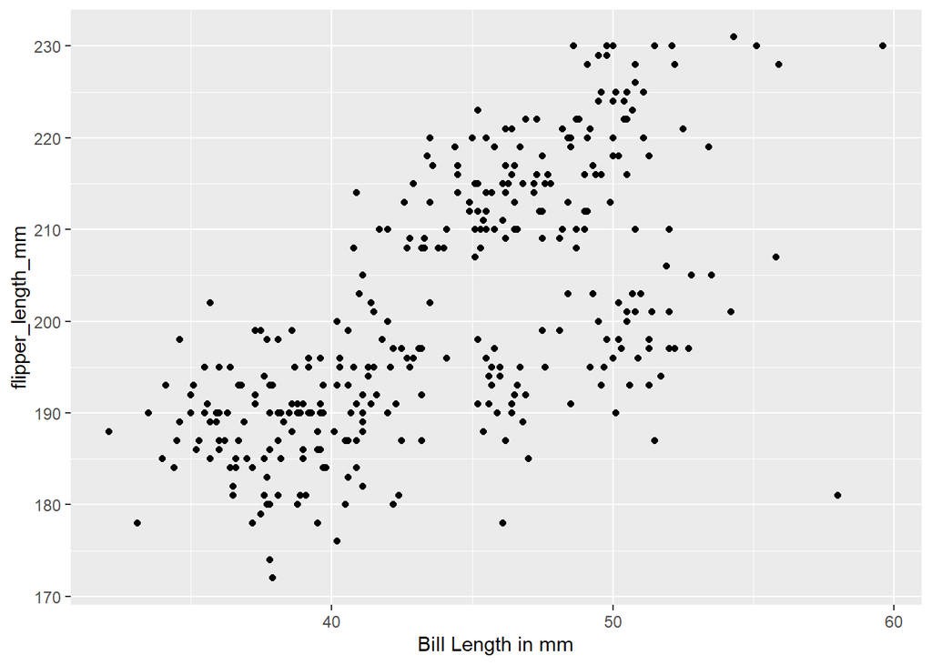

```r
#create plot & designate how many "breaks"

ggplot(penguins,
       aes(x=bill_length_mm,
           y=flipper_length_mm))+
  geom_point() +

  scale_x_continuous(name= "Bill Length in mm",
                     breaks = breaks_pretty(4))
```

```r
  scale_y_continuous(name= "Flipper Length in mm",
                     breaks = breaks_pretty(8))
```

```
## <ScaleContinuousPosition>
##  Range:
##  Limits:    0 --    1
```

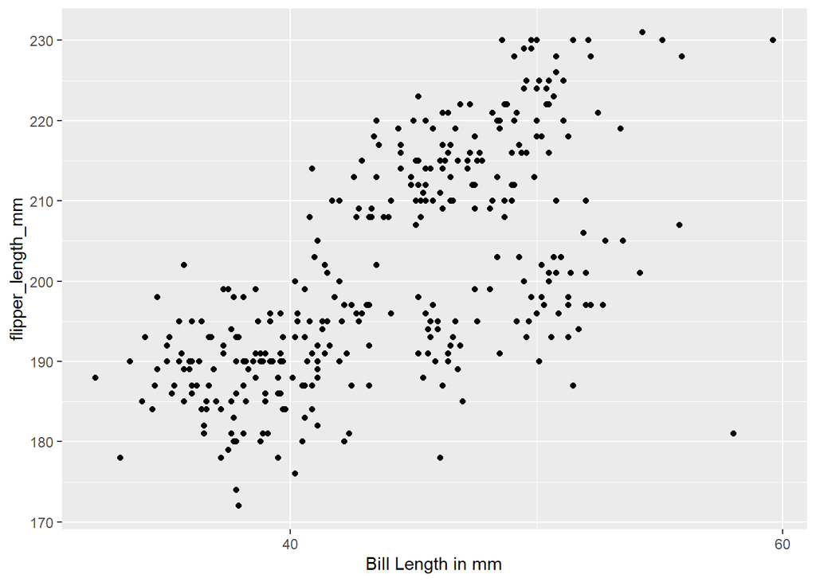

```r
#R doesn't always use the amount of "breaks" that you assign - apparently because it wants to best fit the data. For example - it won't allow for n=50 for y-axis.
ggplot(penguins,
       aes(x=bill_length_mm,
           y=flipper_length_mm))+
  geom_point() +

  scale_x_continuous(name= "Bill Length in mm",
                     breaks = breaks_pretty(2))
```

```r
  scale_y_continuous(name= "Flipper Length in mm",
                     breaks = breaks_pretty(50))
```

```
## <ScaleContinuousPosition>
##  Range:
##  Limits:    0 --    1
```

Here is an example using dates!

```r
one_year <- as.POSIXct(c("2022-01-01", "2023-01-01"))
demo_datetime(one_year)
```

```
## scale_x_datetime()
```

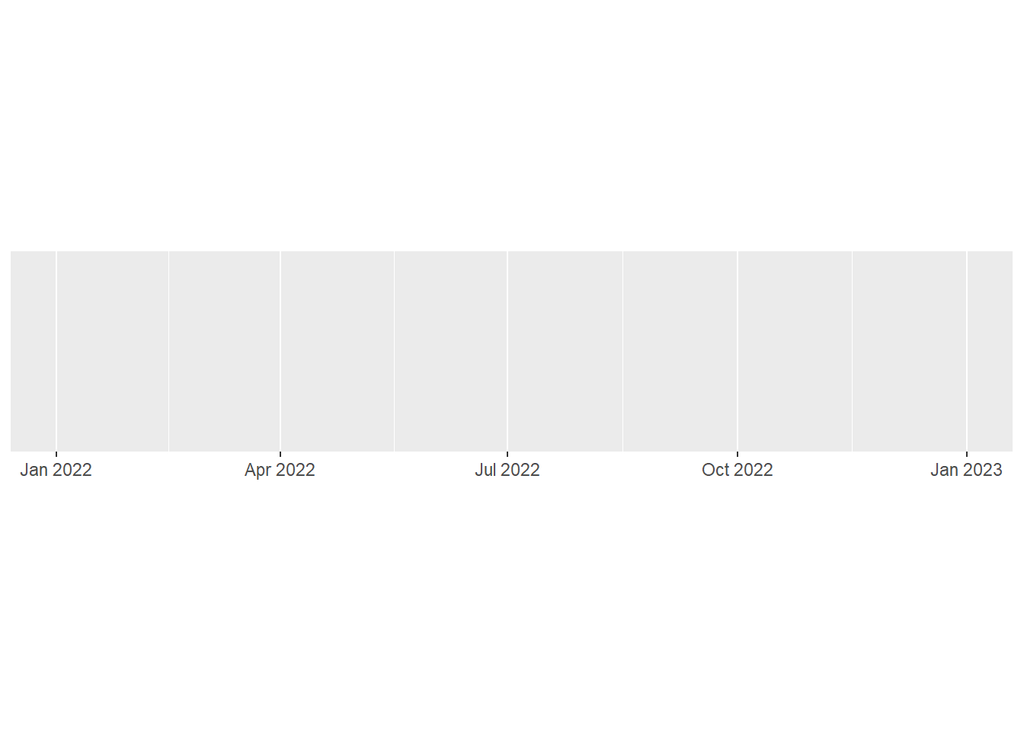

```r
demo_datetime(one_year, breaks = breaks_pretty(12))
```

```
## scale_x_datetime(breaks = breaks_pretty(12))
```

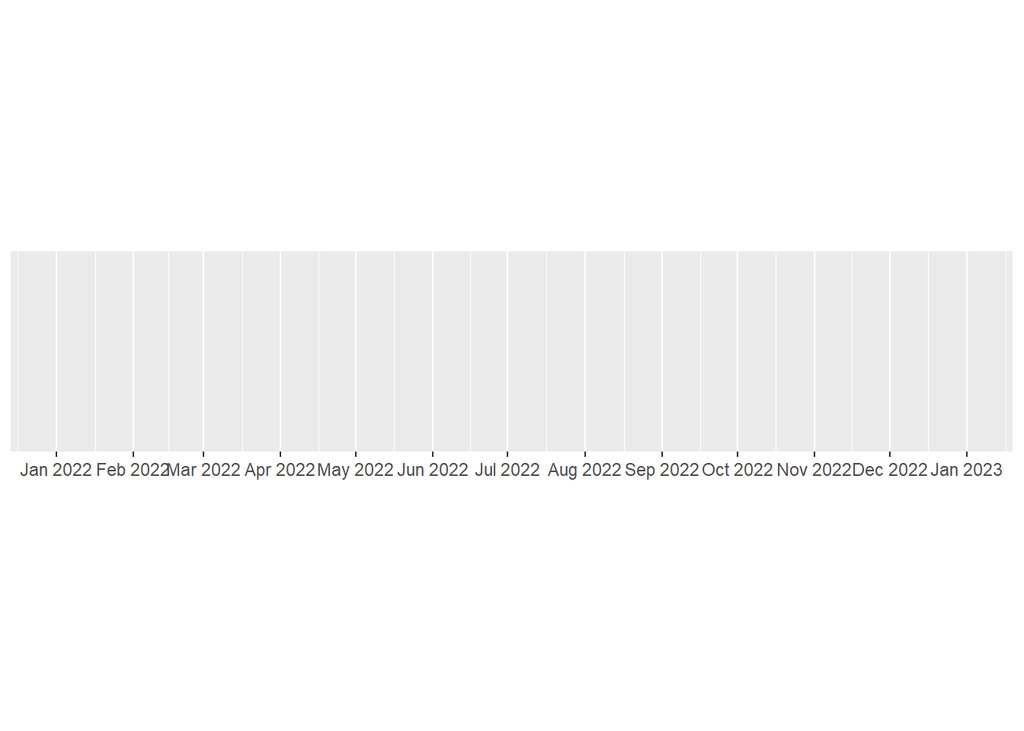

```r
demo_datetime(one_year, breaks = breaks_pretty(6))
```

```
## scale_x_datetime(breaks = breaks_pretty(6))
```

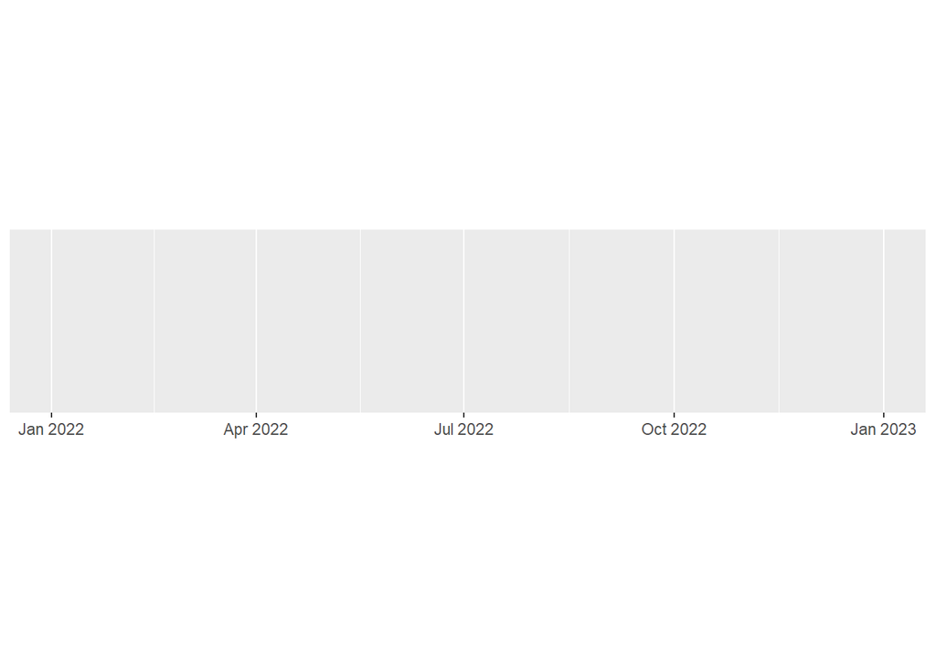

```r
demo_datetime(one_year, breaks = breaks_pretty(100))
```

```
## scale_x_datetime(breaks = breaks_pretty(100))
```

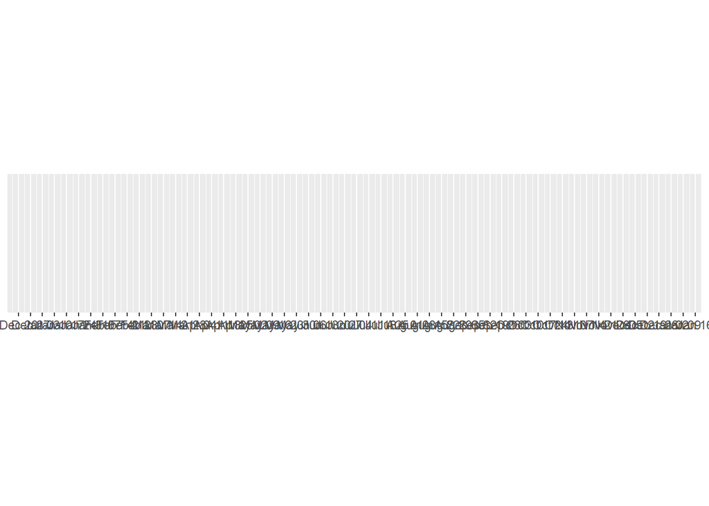

## Is it helpful?

> Discuss whether you think this function is useful for you and your work. Is it the best thing since sliced bread, or is it not really relevant to your work?

I find breaks_pretty much more useful in the dates example! Which makes sense considering it’s not generally used for numerical variables (penguin example).